# projekt - wizualizacja danych

Monika Etrych

18 01 2022

Projekt wykonany w ramach zaliczenia przedmiotu “Wstęp do Analizy Danych”.

# Wykres 1

W jakim wieku ludzie najczęściej próbują popełnić samobójstwo?

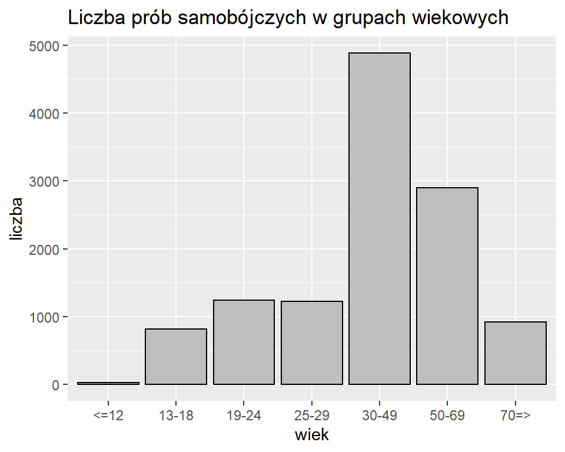

```r
names(wiek)[3:9]=c("<=12","13-18","19-24","25-29","30-49","50-69","70=>")
kolumny = colnames(wiek[3:9])

wiek_wektor = unlist(wiek[1,3:9])

ggplot(wiek[3:9,], aes(kolumny, wiek_wektor))+
  geom_bar(stat="identity", colour="black", fill="grey")+
  labs(x="wiek", y="liczba", title="Liczba prób samobójczych w grupach wiekowych")
```

Najwięcej osób próbujących się zabić jest w przedziale wiekowym 30-49 lat, a następnie 50-69. Najmniej jest w wieku poniżej 12 lat.

# Wykres 2 i 3

2. Jaka jest najskuteczniejsza metoda?
3. Która metoda jest najczęściej stosowana?

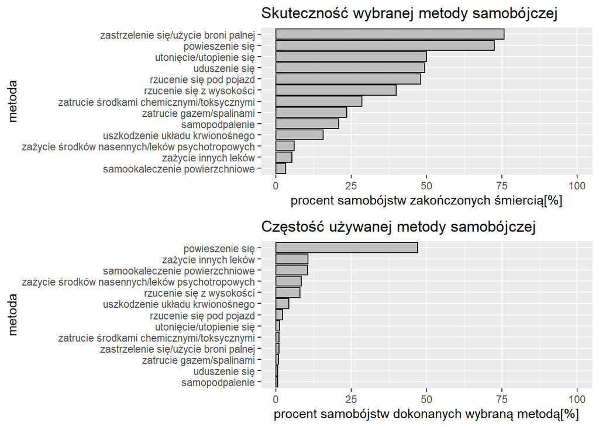

```r
ogolem = colnames(metoda[3:15])
smierc = colnames(metoda[18:30])

ogolem_wektor = unlist(metoda[1,3:15])
smierc_wektor = unlist(metoda[1,18:30])

skutecznosc = smierc_wektor/ogolem_wektor*100
skutecznosc = round(skutecznosc, 3)


p1 = ggplot(metoda[3:15, 18:30,], aes(skutecznosc,reorder(ogolem, skutecznosc)))+
    geom_col(colour="black", fill="grey")+
    xlim(0,100)+
    labs(x="procent samobójstw zakończonych śmiercią[%]", y="metoda", title="Skuteczność wybranej metody samobójczej")

# wykres 3

metoda_ogolem = unlist(metoda[1,3:15])

czestosc_metody=metoda_ogolem/metoda[1,2]*100

p2 = ggplot(metoda[3:15,], aes(czestosc_metody,reorder(ogolem, czestosc_metody)))+
      geom_col(colour="black", fill="grey")+
      labs(x="procent samobójstw dokonanych wybraną metodą[%]", y="metoda", title="Częstość używanej metody samobójczej")+
      xlim(0,100)

grid.arrange(p1, p2, nrow = 2)
```

Chociaż najskuteczniejszą metodą jest użycie broni, to pamiętając, że w Polsce trudno jest uzyskać pozwolenie na broń, jest to rzadko stosowana. Najczęściej stosowaną metodą jest powieszenie, które jest drugą metodą pod względem skuteczności.

# Wykres 4 i 5

4. Kto częściej popełnia samobójstwo kobiety czy mężczyźni?
5. Kto skuteczniej popełnia samobójstwa, kobiety czy mężczyźni?

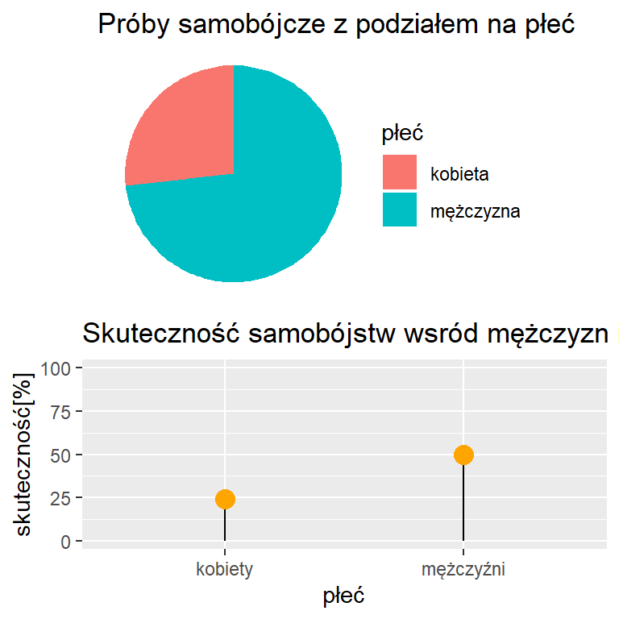

```r
czestosc_kobiety=dane[1,]$kobiety/dane[1,]$ogółem*100
czestosc_mezczyzni = 100-czestosc_kobiety

plec = data.frame(
  płeć=c("kobieta", "mężczyzna"),
  czestosc=c(czestosc_kobiety, czestosc_mezczyzni))

p1 = ggplot(plec, aes(x="", y=czestosc, fill=płeć)) +
    geom_bar(stat="identity", width=1) +
    coord_polar("y", start=0)+
    theme_void()+
    labs(title="Próby samobójcze z podziałem na płeć")

# wykres 5

skutecznosc=data.frame(name=c("kobiety","mężczyźni"),
                       val=c(dane[1,]$`zgon kobiety`/dane[1,]$kobiety*100,
                         dane[1,]$`zgon mężczyźni`/dane[1,]$mężczyźni*100))
p2 = skutecznosc %>%
    ggplot(aes(x=name, y=val)) +
    geom_segment(aes(xend=name, yend=0))+
    geom_point(size=4, color="orange") +
    labs(x="płeć", y="skuteczność[%]", title="Skuteczność samobójstw wsród mężczyzn i kobiet")+
    ylim(0,100)

grid.arrange(p1, p2, nrow = 2)
```

W trakcie tworzenia projektu natrafiłam na informacje, że mężczyźni częściej próbują popełnić samobójstwa, ale kobiety robią, to skuteczniej. Postanowiłam to zbadać. Z danych wynika, że mężczyźni 3-krotnie częściej niż kobiety próbowali się zabić i 2 razy częściej umierali. Teza okazała się fałszywa.

# Wykres 6

Odsetek samobójstw w danym województwie

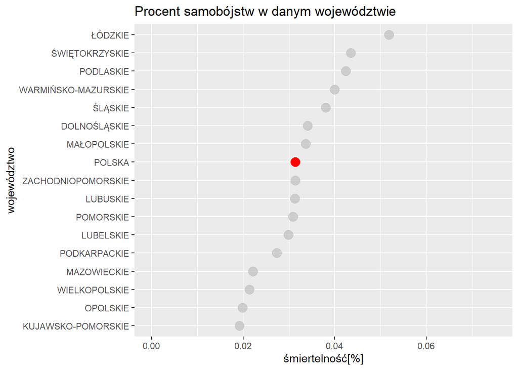

```r
dane%>%
  select(Województwo, ogółem, liczba.ludności)%>%
  mutate(smiertelnosc=ogółem/liczba.ludności*100)%>%
  #filter(Województwo!="POLSKA")%>%
  ggplot(aes(x=smiertelnosc, y=reorder(Województwo, smiertelnosc)))+
  geom_point(size=4, col="red")+
  labs(y="województwo", x="śmiertelność[%]", title="Procent samobójstw w danym województwie")+
  gghighlight(Województwo == "POLSKA")+
  xlim(0,0.075)
```

Proporcjonalnie do liczby ludności w danym województwie najwięcej osób w województwie łódzkim próbowało popełnić samobójstwo. Najmniej w kujawsko-pomorskim. W województwie małopolskim było więcej samobójstw niż średnia dla Polski.